# GammaSleep Supplementary Analyses

L. Hainke, J. Dowsett, M. Spitschan, J. Priller

2024-01-30

# Rationale

Linear interpolation refers to a data cleaning step employed to remove periodic artifacts. Here, such artifacts have occasionally been caused by the LEDs of the custom sleep mask placed directly over subjects’ eyes, and therefore close to EEG electrodes. At the intended stimulation frequency of 40 Hz and a duty cycle of 50 %, the LEDs were programmed to go ON at timepoint 0 of each 25 ms segment, and OFF at 12.5 ms. The mask was built to be shielded as well as possible, however, SSVEPs were computed from a very high number of segments. While this is favourable to average out noise overall, any electric contamination by the LEDs would be very consistent in timing, and therefore visible in the averaged time series.  
The image below shows an SSVEP particularly affected by this issue, with one downward and one upward peak distorting the underlying sinusoidal waveform. The red dashed lines simbolize the linear interpolation procedure: Essentially, datapoints at the beginning (timepoints [-1;3]) and middle (timepoints [11;15]) of each segment are replaced with a straight line. Averaging across “cleaned” segments then results in a sinusoidal form, without residuals of LED ON/OFF artifacts.

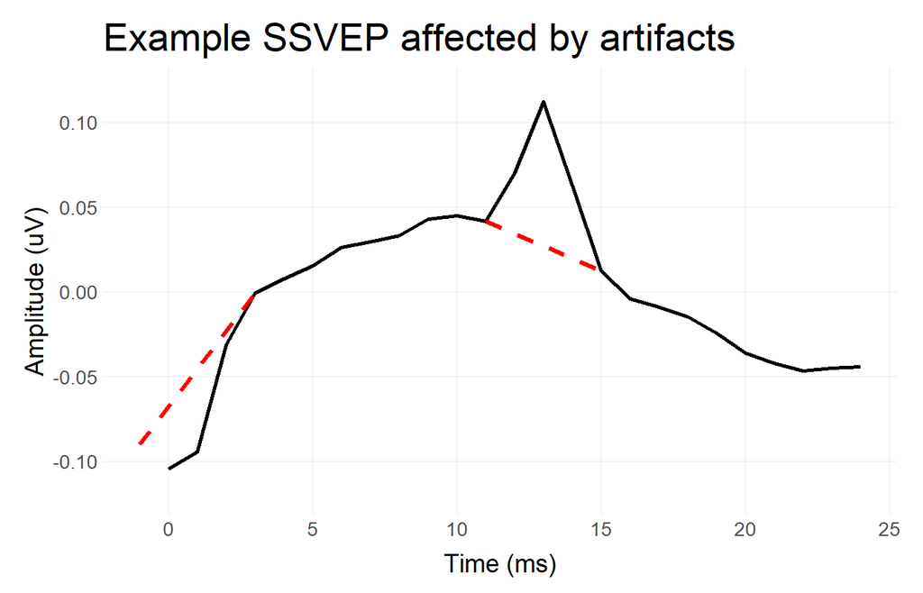

This procedure was not defined in the preregistration, since pilot data were not affected by artifacts. In fact, neither was the majority of the datasets. Given that the presence or absence of artifacts is constant within participants, and comparisons between conditions were carried out within-subjects, artifacts do not distort pairwise comparison results. For those reasons, linear interpolation was not applied to main analyses. Nevertheless, since some SSVEPs showed these characteristic peaks, we report results with this processing step applied here. In short, **the results of confirmatory analyses do not change**.

# Confirmatory Analysis [EEG Power Spectral Density]

## H1: W<sub>exp</sub> > W<sub>con</sub>

```
## RESULTS: PAIRED T-TEST
##
## P-value: 2.890659e-10
##
## Effect size:
## d (z) |       95% CI
## --------------------
## 1.61  | [1.08, 2.15]
##
## - Adjusted for small sample bias.
```

## H2: N2<sub>exp</sub> > N2<sub>con</sub>

```
## RESULTS: PAIRED T-TEST
##
## P-value: 0.001218355
##
## Effect size:
## d (z) |       95% CI
## --------------------
## 0.59  | [0.21, 0.97]
##
## - Adjusted for small sample bias.
```

## H3: N3<sub>exp</sub> > N3<sub>con</sub>

```
## RESULTS: PAIRED T-TEST
##
## P-value: 0.001203977
##
## Effect size:
## d (z) |       95% CI
## --------------------
## 0.59  | [0.21, 0.97]
##
## - Adjusted for small sample bias.
```

## H4: REM<sub>exp</sub> > REM<sub>con</sub>

```
## RESULTS: PAIRED WILCOXON SIGNED RANK TEST
##
## P-value: 4.004687e-08
##
## Effect size:
## r (rank biserial) |       95% CI
## --------------------------------
## 0.96              | [0.92, 1.00]
##
## - One-sided CIs: upper bound fixed at [1.00].
```

## H5: W<sub>exp</sub> =/= N2<sub>exp</sub> =/= N3<sub>exp</sub> =/= REM<sub>exp</sub>

```
## RESULTS: REPEATED-MEASURES ANOVA
##
## P-value: 2.658055e-172
##
## # Effect Size for ANOVA
##
## Eta2 (partial) |   CI | CI_low
## ------------------------------
## 0.90           | 0.95 |   0.87
##
##
## Bonferroni-corrected post-hoc tests:
##               N2           N3          REM
## N3  1.000000e+00           NA           NA
## REM 1.000000e+00 1.000000e+00           NA
## W   9.554882e-25 2.030124e-26 6.744137e-24
```

## SNR - PSD40

Consistent with confirmatory analyses, all median SNR values for the variable PSD40 are ~1 in the control condition, and all SNR values are >1 in the experimental condition, with a markedly higher value in W<sub>exp</sub>.

```
##  stage condition     value
##     N2       con  1.050865
##     N3       con  1.044413
##    REM       con  1.071206
##      W       con  1.029764
##     N2       exp  1.990740
##     N3       exp  1.590922
##    REM       exp  2.282790
##      W       exp 16.038337
```

# SSVEPs

The following plots depict the **SSVEPs, interpolated and averaged** across all subjects, by stage and condition.

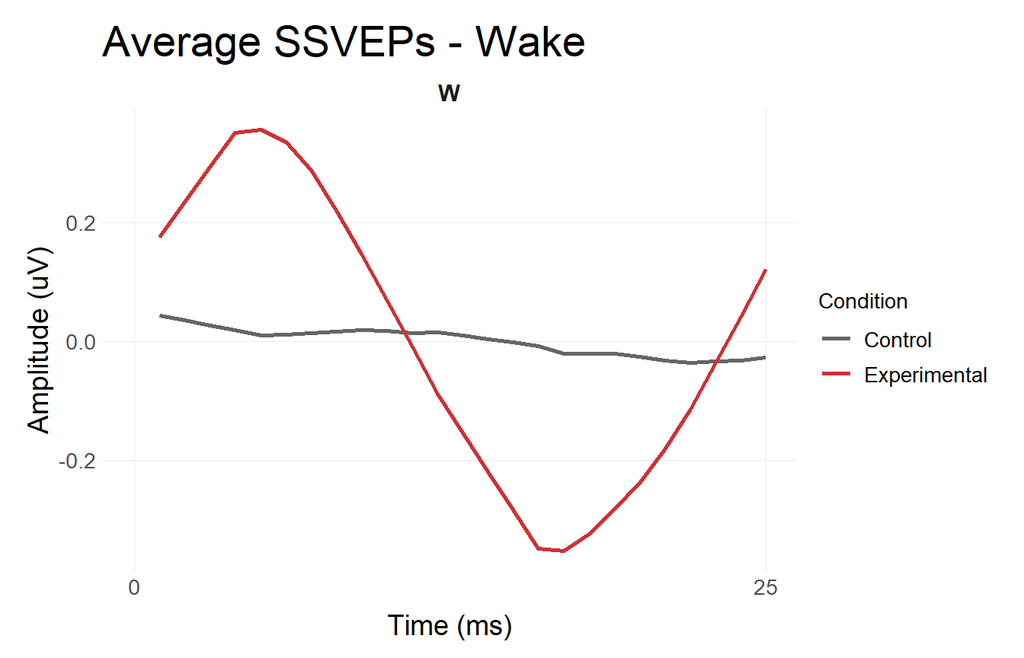

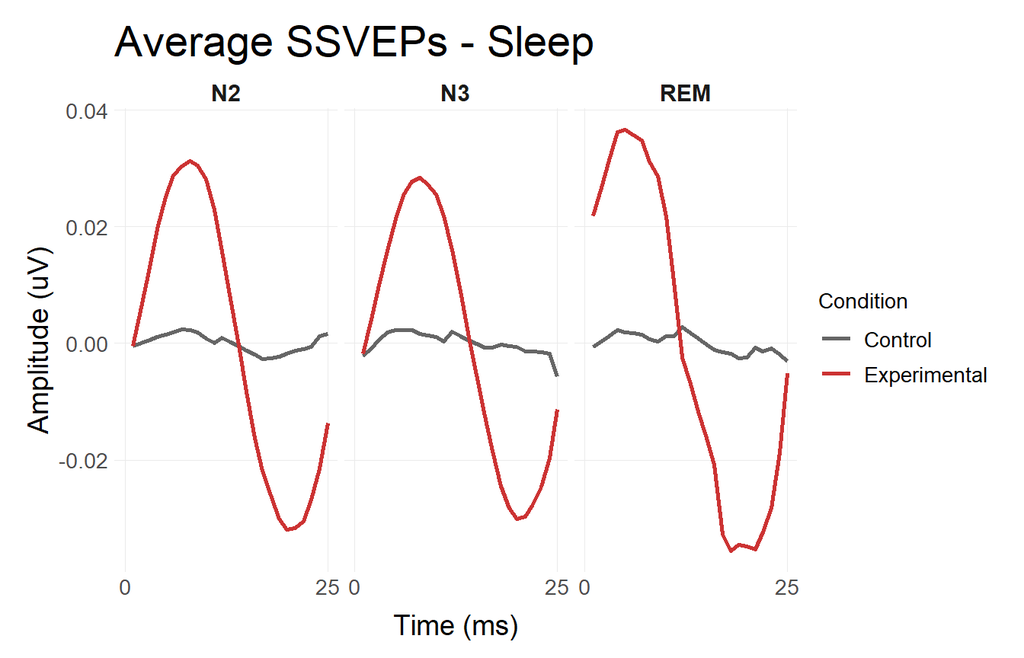

## SNR - SSVEPamp

```
##  stage condition     value
##     N2       con 0.7368616
##     N3       con 0.5043904
##    REM       con 0.5331788
##      W       con 1.2614076
##     N2       exp 2.2558143
##     N3       exp 1.4473527
##    REM       exp 1.9877709
##      W       exp 6.5245720
```